# Project: Ford Go-bike system data

- Introduction
- Data Wrangling
- Exploratory Data Analysis
- Explanatory
- Conclusions

## Introduction

> I will analyze and explore data from Ford Go-bike system Dataset , this data icludes information about individual rides made in a bike-sharing system covering the greater San Francisco Bay area. This data set contains information about 183,000 rides collected from bike-sharing system, including 16 different variables like ride duration, start & end times for each trib , location for start & end stations , gender , member birth year and and other atrractive information to be explored .

```python
import numpy as np
import pandas as pd
import matplotlib.pyplot as plt
import seaborn as sb
%matplotlib inline
from scipy import stats
import datetime
```

## Data Wrangling

```python
df = pd.read_csv('201902-fordgobike-tripdata.csv')
print(df.shape)
df.head()
```

```
(183412, 16)
```

|  | duration_sec | start_time | end_time | start_station_id | start_station_name | start_station_latitude | start_station_longitude | end_station_id | end_station_name | end_station_latitude | end_station_longitude | bike_id | user_type | member_birth_year | member_gender | bike_share_for_all_trip |
| --- | --- | --- | --- | --- | --- | --- | --- | --- | --- | --- | --- | --- | --- | --- | --- | --- |
| 0 | 52185 | 2019-02-28 17:32:10.1450 | 2019-03-01 08:01:55.9750 | 21.0 | Montgomery St BART Station (Market St at 2nd St) | 37.789625 | -122.400811 | 13.0 | Commercial St at Montgomery St | 37.794231 | -122.402923 | 4902 | Customer | 1984.0 | Male | No |
| 1 | 42521 | 2019-02-28 18:53:21.7890 | 2019-03-01 06:42:03.0560 | 23.0 | The Embarcadero at Steuart St | 37.791464 | -122.391034 | 81.0 | Berry St at 4th St | 37.775880 | -122.393170 | 2535 | Customer | NaN | NaN | No |
| 2 | 61854 | 2019-02-28 12:13:13.2180 | 2019-03-01 05:24:08.1460 | 86.0 | Market St at Dolores St | 37.769305 | -122.426826 | 3.0 | Powell St BART Station (Market St at 4th St) | 37.786375 | -122.404904 | 5905 | Customer | 1972.0 | Male | No |
| 3 | 36490 | 2019-02-28 17:54:26.0100 | 2019-03-01 04:02:36.8420 | 375.0 | Grove St at Masonic Ave | 37.774836 | -122.446546 | 70.0 | Central Ave at Fell St | 37.773311 | -122.444293 | 6638 | Subscriber | 1989.0 | Other | No |
| 4 | 1585 | 2019-02-28 23:54:18.5490 | 2019-03-01 00:20:44.0740 | 7.0 | Frank H Ogawa Plaza | 37.804562 | -122.271738 | 222.0 | 10th Ave at E 15th St | 37.792714 | -122.248780 | 4898 | Subscriber | 1974.0 | Male | Yes |

```python
df.info()
```

```
<class 'pandas.core.frame.DataFrame'>
RangeIndex: 183412 entries, 0 to 183411
Data columns (total 16 columns):
 #   Column                   Non-Null Count   Dtype
---  ------                   --------------   -----
 0   duration_sec             183412 non-null  int64
 1   start_time               183412 non-null  object
 2   end_time                 183412 non-null  object
 3   start_station_id         183215 non-null  float64
 4   start_station_name       183215 non-null  object
 5   start_station_latitude   183412 non-null  float64
 6   start_station_longitude  183412 non-null  float64
 7   end_station_id           183215 non-null  float64
 8   end_station_name         183215 non-null  object
 9   end_station_latitude     183412 non-null  float64
 10  end_station_longitude    183412 non-null  float64
 11  bike_id                  183412 non-null  int64
 12  user_type                183412 non-null  object
 13  member_birth_year        175147 non-null  float64
 14  member_gender            175147 non-null  object
 15  bike_share_for_all_trip  183412 non-null  object
dtypes: float64(7), int64(2), object(7)
memory usage: 22.4+ MB
```

### To be clean

- convert duration_sec to duration minutes
- start & end time to date time
- all ids to object
- latitude and longitude to object
- make new column to start and end stations location
- user type category
- birth year to object
- gender to category
- bike_share_for_all_trip to category

```python
df.describe()
```

|  | duration_sec | start_station_id | start_station_latitude | start_station_longitude | end_station_id | end_station_latitude | end_station_longitude | bike_id | member_birth_year |
| --- | --- | --- | --- | --- | --- | --- | --- | --- | --- |
| count | 183412.000000 | 183215.000000 | 183412.000000 | 183412.000000 | 183215.000000 | 183412.000000 | 183412.000000 | 183412.000000 | 175147.000000 |
| mean | 726.078435 | 138.590427 | 37.771223 | -122.352664 | 136.249123 | 37.771427 | -122.352250 | 4472.906375 | 1984.806437 |
| std | 1794.389780 | 111.778864 | 0.099581 | 0.117097 | 111.515131 | 0.099490 | 0.116673 | 1664.383394 | 10.116689 |
| min | 61.000000 | 3.000000 | 37.317298 | -122.453704 | 3.000000 | 37.317298 | -122.453704 | 11.000000 | 1878.000000 |
| 25% | 325.000000 | 47.000000 | 37.770083 | -122.412408 | 44.000000 | 37.770407 | -122.411726 | 3777.000000 | 1980.000000 |
| 50% | 514.000000 | 104.000000 | 37.780760 | -122.398285 | 100.000000 | 37.781010 | -122.398279 | 4958.000000 | 1987.000000 |
| 75% | 796.000000 | 239.000000 | 37.797280 | -122.286533 | 235.000000 | 37.797320 | -122.288045 | 5502.000000 | 1992.000000 |
| max | 85444.000000 | 398.000000 | 37.880222 | -121.874119 | 398.000000 | 37.880222 | -121.874119 | 6645.000000 | 2001.000000 |

```python
df.duration_sec.sort_values(ascending = True)
```

```
169882       61
157305       61
103565       61
44787        61
44301        61
          ...
112435    83407
127999    83519
153705    83772
85465     84548
101361    85444
Name: duration_sec, Length: 183412, dtype: int64
```

```python
df[df['member_birth_year'] < 1919]  #unlogic #convert to nan.
```

|  | duration_sec | start_time | end_time | start_station_id | start_station_name | start_station_latitude | start_station_longitude | end_station_id | end_station_name | end_station_latitude | end_station_longitude | bike_id | user_type | member_birth_year | member_gender | bike_share_for_all_trip |
| --- | --- | --- | --- | --- | --- | --- | --- | --- | --- | --- | --- | --- | --- | --- | --- | --- |
| 1285 | 148 | 2019-02-28 19:29:17.6270 | 2019-02-28 19:31:45.9670 | 158.0 | Shattuck Ave at Telegraph Ave | 37.833279 | -122.263490 | 173.0 | Shattuck Ave at 55th St | 37.840364 | -122.264488 | 5391 | Subscriber | 1900.0 | Male | Yes |
| 10827 | 1315 | 2019-02-27 19:21:34.4360 | 2019-02-27 19:43:30.0080 | 343.0 | Bryant St at 2nd St | 37.783172 | -122.393572 | 375.0 | Grove St at Masonic Ave | 37.774836 | -122.446546 | 6249 | Subscriber | 1900.0 | Male | No |
| 16087 | 1131 | 2019-02-27 08:37:36.8640 | 2019-02-27 08:56:28.0220 | 375.0 | Grove St at Masonic Ave | 37.774836 | -122.446546 | 36.0 | Folsom St at 3rd St | 37.783830 | -122.398870 | 4968 | Subscriber | 1900.0 | Male | No |
| 19375 | 641 | 2019-02-26 17:03:19.8550 | 2019-02-26 17:14:01.6190 | 9.0 | Broadway at Battery St | 37.798572 | -122.400869 | 30.0 | San Francisco Caltrain (Townsend St at 4th St) | 37.776598 | -122.395282 | 6164 | Customer | 1900.0 | Male | No |
| 21424 | 1424 | 2019-02-26 08:58:02.9040 | 2019-02-26 09:21:47.7490 | 375.0 | Grove St at Masonic Ave | 37.774836 | -122.446546 | 343.0 | Bryant St at 2nd St | 37.783172 | -122.393572 | 5344 | Subscriber | 1900.0 | Male | No |
| ... | ... | ... | ... | ... | ... | ... | ... | ... | ... | ... | ... | ... | ... | ... | ... | ... |
| 171996 | 1368 | 2019-02-03 17:33:54.6070 | 2019-02-03 17:56:42.9490 | 37.0 | 2nd St at Folsom St | 37.785000 | -122.395936 | 375.0 | Grove St at Masonic Ave | 37.774836 | -122.446546 | 4988 | Subscriber | 1900.0 | Male | No |
| 173711 | 993 | 2019-02-03 09:45:30.4640 | 2019-02-03 10:02:04.1690 | 375.0 | Grove St at Masonic Ave | 37.774836 | -122.446546 | 36.0 | Folsom St at 3rd St | 37.783830 | -122.398870 | 5445 | Subscriber | 1900.0 | Male | No |
| 177708 | 1527 | 2019-02-01 19:09:28.3870 | 2019-02-01 19:34:55.9630 | 343.0 | Bryant St at 2nd St | 37.783172 | -122.393572 | 375.0 | Grove St at Masonic Ave | 37.774836 | -122.446546 | 5286 | Subscriber | 1900.0 | Male | No |
| 177885 | 517 | 2019-02-01 18:38:40.4710 | 2019-02-01 18:47:18.3920 | 25.0 | Howard St at 2nd St | 37.787522 | -122.397405 | 30.0 | San Francisco Caltrain (Townsend St at 4th St) | 37.776598 | -122.395282 | 2175 | Subscriber | 1902.0 | Female | No |
| 182830 | 428 | 2019-02-01 07:45:05.9340 | 2019-02-01 07:52:14.9220 | 284.0 | Yerba Buena Center for the Arts (Howard St at ... | 37.784872 | -122.400876 | 67.0 | San Francisco Caltrain Station 2 (Townsend St... | 37.776639 | -122.395526 | 5031 | Subscriber | 1901.0 | Male | No |

72 rows × 16 columns

```python
df[df['start_station_id'].isnull()]
# i will keep it and won't drop it because the location of stations and all other data existed.
```

|  | duration_sec | start_time | end_time | start_station_id | start_station_name | start_station_latitude | start_station_longitude | end_station_id | end_station_name | end_station_latitude | end_station_longitude | bike_id | user_type | member_birth_year | member_gender | bike_share_for_all_trip |
| --- | --- | --- | --- | --- | --- | --- | --- | --- | --- | --- | --- | --- | --- | --- | --- | --- |
| 475 | 1709 | 2019-02-28 20:55:53.9320 | 2019-02-28 21:24:23.7380 | NaN | NaN | 37.40 | -121.94 | NaN | NaN | 37.40 | -121.93 | 4211 | Customer | 1991.0 | Female | No |
| 1733 | 1272 | 2019-02-28 18:32:34.2730 | 2019-02-28 18:53:46.7270 | NaN | NaN | 37.40 | -121.94 | NaN | NaN | 37.41 | -121.96 | 4174 | Subscriber | 1980.0 | Male | No |
| 3625 | 142 | 2019-02-28 17:10:46.5290 | 2019-02-28 17:13:09.4310 | NaN | NaN | 37.41 | -121.95 | NaN | NaN | 37.41 | -121.96 | 4283 | Subscriber | 1988.0 | Male | No |
| 4070 | 585 | 2019-02-28 16:28:45.9340 | 2019-02-28 16:38:31.3320 | NaN | NaN | 37.39 | -121.93 | NaN | NaN | 37.40 | -121.92 | 4089 | Subscriber | 1984.0 | Male | Yes |
| 5654 | 509 | 2019-02-28 12:30:17.1310 | 2019-02-28 12:38:46.3290 | NaN | NaN | 37.40 | -121.92 | NaN | NaN | 37.39 | -121.93 | 4089 | Subscriber | 1984.0 | Male | Yes |
| ... | ... | ... | ... | ... | ... | ... | ... | ... | ... | ... | ... | ... | ... | ... | ... | ... |
| 176154 | 1447 | 2019-02-02 12:03:04.5440 | 2019-02-02 12:27:12.2670 | NaN | NaN | 37.40 | -121.93 | NaN | NaN | 37.40 | -121.93 | 4249 | Customer | 1984.0 | Male | No |
| 179730 | 309 | 2019-02-01 12:59:45.9690 | 2019-02-01 13:04:55.4260 | NaN | NaN | 37.40 | -121.94 | NaN | NaN | 37.40 | -121.93 | 4249 | Customer | 1987.0 | Female | No |
| 179970 | 659 | 2019-02-01 12:17:37.6750 | 2019-02-01 12:28:37.0140 | NaN | NaN | 37.41 | -121.96 | NaN | NaN | 37.41 | -121.94 | 4092 | Subscriber | 1999.0 | Female | No |
| 180106 | 2013 | 2019-02-01 11:33:55.1470 | 2019-02-01 12:07:28.9400 | NaN | NaN | 37.40 | -121.94 | NaN | NaN | 37.40 | -121.94 | 4251 | Customer | 1990.0 | Female | No |
| 181201 | 312 | 2019-02-01 09:26:34.8030 | 2019-02-01 09:31:46.9210 | NaN | NaN | 37.40 | -121.93 | NaN | NaN | 37.40 | -121.93 | 4208 | Subscriber | 1987.0 | Male | No |

197 rows × 16 columns

```python
df[df['member_birth_year'].isnull()]
# i will accept it , the data of gender and birth year for about 8265 rides are dropped
# from csv file and other data are existed.
```

|  | duration_sec | start_time | end_time | start_station_id | start_station_name | start_station_latitude | start_station_longitude | end_station_id | end_station_name | end_station_latitude | end_station_longitude | bike_id | user_type | member_birth_year | member_gender | bike_share_for_all_trip |
| --- | --- | --- | --- | --- | --- | --- | --- | --- | --- | --- | --- | --- | --- | --- | --- | --- |
| 1 | 42521 | 2019-02-28 18:53:21.7890 | 2019-03-01 06:42:03.0560 | 23.0 | The Embarcadero at Steuart St | 37.791464 | -122.391034 | 81.0 | Berry St at 4th St | 37.775880 | -122.393170 | 2535 | Customer | NaN | NaN | No |
| 13 | 915 | 2019-02-28 23:49:06.0620 | 2019-03-01 00:04:21.8670 | 252.0 | Channing Way at Shattuck Ave | 37.865847 | -122.267443 | 244.0 | Shattuck Ave at Hearst Ave | 37.873676 | -122.268487 | 5101 | Subscriber | NaN | NaN | No |
| 28 | 650 | 2019-02-28 23:43:27.5030 | 2019-02-28 23:54:18.4510 | 258.0 | University Ave at Oxford St | 37.872355 | -122.266447 | 263.0 | Channing Way at San Pablo Ave | 37.862827 | -122.290231 | 4784 | Customer | NaN | NaN | No |
| 53 | 3418 | 2019-02-28 22:41:16.3620 | 2019-02-28 23:38:14.3630 | 11.0 | Davis St at Jackson St | 37.797280 | -122.398436 | 11.0 | Davis St at Jackson St | 37.797280 | -122.398436 | 319 | Customer | NaN | NaN | No |
| 65 | 926 | 2019-02-28 23:17:05.8530 | 2019-02-28 23:32:32.6820 | 13.0 | Commercial St at Montgomery St | 37.794231 | -122.402923 | 81.0 | Berry St at 4th St | 37.775880 | -122.393170 | 2951 | Subscriber | NaN | NaN | No |
| ... | ... | ... | ... | ... | ... | ... | ... | ... | ... | ... | ... | ... | ... | ... | ... | ... |
| 183354 | 449 | 2019-02-01 01:35:07.6630 | 2019-02-01 01:42:36.8780 | 244.0 | Shattuck Ave at Hearst Ave | 37.873676 | -122.268487 | 253.0 | Haste St at College Ave | 37.866418 | -122.253799 | 5430 | Customer | NaN | NaN | No |
| 183356 | 795 | 2019-02-01 01:25:50.3660 | 2019-02-01 01:39:05.9500 | 368.0 | Myrtle St at Polk St | 37.785434 | -122.419622 | 125.0 | 20th St at Bryant St | 37.759200 | -122.409851 | 5400 | Subscriber | NaN | NaN | No |
| 183363 | 673 | 2019-02-01 01:12:24.4200 | 2019-02-01 01:23:37.6450 | 75.0 | Market St at Franklin St | 37.773793 | -122.421239 | 133.0 | Valencia St at 22nd St | 37.755213 | -122.420975 | 5166 | Customer | NaN | NaN | No |
| 183371 | 196 | 2019-02-01 01:08:38.6410 | 2019-02-01 01:11:54.9490 | 58.0 | Market St at 10th St | 37.776619 | -122.417385 | 75.0 | Market St at Franklin St | 37.773793 | -122.421239 | 2395 | Customer | NaN | NaN | No |
| 183402 | 122 | 2019-02-01 00:17:32.2580 | 2019-02-01 00:19:34.9380 | 119.0 | 18th St at Noe St | 37.761047 | -122.432642 | 120.0 | Mission Dolores Park | 37.761420 | -122.426435 | 4326 | Subscriber | NaN | NaN | No |

8265 rows × 16 columns

```python
df.member_gender.isnull().sum()
```

```
8265
```

```python
df.sample(30)
```

|  | duration_sec | start_time | end_time | start_station_id | start_station_name | start_station_latitude | start_station_longitude | end_station_id | end_station_name | end_station_latitude | end_station_longitude | bike_id | user_type | member_birth_year | member_gender | bike_share_for_all_trip |
| --- | --- | --- | --- | --- | --- | --- | --- | --- | --- | --- | --- | --- | --- | --- | --- | --- |
| 61707 | 516 | 2019-02-20 17:29:43.9920 | 2019-02-20 17:38:20.9510 | 349.0 | Howard St at Mary St | 37.781010 | -122.405666 | 114.0 | Rhode Island St at 17th St | 37.764478 | -122.402570 | 5341 | Subscriber | 1982.0 | Male | No |
| 95474 | 623 | 2019-02-15 13:37:53.5890 | 2019-02-15 13:48:16.7480 | 43.0 | San Francisco Public Library (Grove St at Hyde... | 37.778768 | -122.415929 | 93.0 | 4th St at Mission Bay Blvd S | 37.770407 | -122.391198 | 5548 | Subscriber | 1989.0 | Male | No |
| 138977 | 826 | 2019-02-07 23:32:14.8670 | 2019-02-07 23:46:01.0080 | 195.0 | Bay Pl at Vernon St | 37.812314 | -122.260779 | 194.0 | Lakeshore Ave at Trestle Glen Rd | 37.811081 | -122.243268 | 4577 | Subscriber | 1990.0 | Female | No |
| 4583 | 937 | 2019-02-28 15:24:32.8240 | 2019-02-28 15:40:09.9200 | 14.0 | Clay St at Battery St | 37.795001 | -122.399970 | 30.0 | San Francisco Caltrain (Townsend St at 4th St) | 37.776598 | -122.395282 | 5914 | Subscriber | 1977.0 | Female | No |
| 103518 | 86 | 2019-02-14 12:39:01.5290 | 2019-02-14 12:40:27.7890 | 90.0 | Townsend St at 7th St | 37.771058 | -122.402717 | 350.0 | 8th St at Brannan St | 37.771431 | -122.405787 | 4967 | Subscriber | 1964.0 | Male | No |
| 76265 | 831 | 2019-02-19 08:22:03.3540 | 2019-02-19 08:35:54.8240 | 31.0 | Raymond Kimbell Playground | 37.783813 | -122.434559 | 14.0 | Clay St at Battery St | 37.795001 | -122.399970 | 5163 | Subscriber | 1984.0 | Male | No |
| 20321 | 2062 | 2019-02-26 12:45:26.7480 | 2019-02-26 13:19:48.9440 | 22.0 | Howard St at Beale St | 37.789756 | -122.394643 | 66.0 | 3rd St at Townsend St | 37.778742 | -122.392741 | 5564 | Subscriber | 1992.0 | Male | No |
| 29625 | 468 | 2019-02-25 07:01:09.5100 | 2019-02-25 07:08:58.0650 | 213.0 | 32nd St at Adeline St | 37.823847 | -122.281193 | 160.0 | West Oakland BART Station | 37.805318 | -122.294837 | 6391 | Subscriber | 1986.0 | Female | No |
| 42307 | 750 | 2019-02-22 17:35:47.1390 | 2019-02-22 17:48:17.5020 | 60.0 | 8th St at Ringold St | 37.774520 | -122.409449 | 15.0 | San Francisco Ferry Building (Harry Bridges Pl... | 37.795392 | -122.394203 | 4939 | Subscriber | 1980.0 | Male | No |
| 107003 | 573 | 2019-02-13 17:07:00.6760 | 2019-02-13 17:16:34.5290 | 317.0 | San Salvador St at 9th St | 37.333955 | -121.877349 | 357.0 | 2nd St at Julian St | 37.341132 | -121.892844 | 4031 | Subscriber | 1994.0 | Male | Yes |
| 5921 | 490 | 2019-02-28 11:46:43.8930 | 2019-02-28 11:54:54.2180 | 47.0 | 4th St at Harrison St | 37.780955 | -122.399749 | 20.0 | Mechanics Monument Plaza (Market St at Bush St) | 37.791300 | -122.399051 | 4427 | Subscriber | 1972.0 | Female | No |
| 107228 | 476 | 2019-02-13 16:44:27.9540 | 2019-02-13 16:52:24.3940 | 13.0 | Commercial St at Montgomery St | 37.794231 | -122.402923 | 15.0 | San Francisco Ferry Building (Harry Bridges Pl... | 37.795392 | -122.394203 | 4383 | Subscriber | 1987.0 | Female | No |
| 69111 | 697 | 2019-02-19 20:07:01.9480 | 2019-02-19 20:18:39.9170 | 5.0 | Powell St BART Station (Market St at 5th St) | 37.783899 | -122.408445 | 350.0 | 8th St at Brannan St | 37.771431 | -122.405787 | 6095 | Subscriber | 1988.0 | Male | No |
| 162708 | 394 | 2019-02-05 10:30:17.7870 | 2019-02-05 10:36:52.4100 | 311.0 | Paseo De San Antonio at 2nd St | 37.333798 | -121.886943 | 280.0 | San Fernando St at 7th St | 37.337122 | -121.883215 | 3894 | Subscriber | 1992.0 | Female | Yes |
| 85198 | 949 | 2019-02-17 15:40:21.2180 | 2019-02-17 15:56:10.6430 | 6.0 | The Embarcadero at Sansome St | 37.804770 | -122.403234 | 8.0 | The Embarcadero at Vallejo St | 37.799953 | -122.398525 | 6448 | Customer | 2000.0 | Male | No |
| 137029 | 381 | 2019-02-08 09:05:00.2820 | 2019-02-08 09:11:21.6430 | 30.0 | San Francisco Caltrain (Townsend St at 4th St) | 37.776598 | -122.395282 | 350.0 | 8th St at Brannan St | 37.771431 | -122.405787 | 5348 | Subscriber | 1983.0 | Male | No |
| 27053 | 564 | 2019-02-25 10:16:07.3570 | 2019-02-25 10:25:32.1320 | 290.0 | George St at 1st St | 37.347732 | -121.899464 | 279.0 | Santa Clara St at 7th St | 37.339146 | -121.884105 | 6616 | Subscriber | 1996.0 | Female | No |
| 170066 | 483 | 2019-02-04 08:35:41.2900 | 2019-02-04 08:43:45.2220 | 108.0 | 16th St Mission BART | 37.764710 | -122.419957 | 78.0 | Folsom St at 9th St | 37.773717 | -122.411647 | 3508 | Subscriber | NaN | NaN | No |
| 33 | 638 | 2019-02-28 23:40:32.2730 | 2019-02-28 23:51:10.6390 | 98.0 | Valencia St at 16th St | 37.765052 | -122.421866 | 373.0 | Potrero del Sol Park (25th St at Utah St) | 37.751792 | -122.405216 | 6435 | Subscriber | 1973.0 | Male | No |
| 142146 | 827 | 2019-02-07 17:17:00.1040 | 2019-02-07 17:30:47.5020 | 321.0 | 5th St at Folsom | 37.780146 | -122.403071 | 130.0 | 22nd St Caltrain Station | 37.757288 | -122.392051 | 6638 | Subscriber | 1982.0 | Male | No |
| 70786 | 292 | 2019-02-19 18:02:19.9450 | 2019-02-19 18:07:12.4070 | 176.0 | MacArthur BART Station | 37.828410 | -122.266315 | 212.0 | Mosswood Park | 37.824893 | -122.260437 | 1449 | Subscriber | 1994.0 | Male | No |
| 55504 | 417 | 2019-02-21 10:03:18.0810 | 2019-02-21 10:10:15.4130 | 324.0 | Union Square (Powell St at Post St) | 37.788300 | -122.408531 | 16.0 | Steuart St at Market St | 37.794130 | -122.394430 | 5389 | Subscriber | 1990.0 | Other | No |
| 140232 | 990 | 2019-02-07 19:13:25.7030 | 2019-02-07 19:29:55.9840 | 24.0 | Spear St at Folsom St | 37.789677 | -122.390428 | 114.0 | Rhode Island St at 17th St | 37.764478 | -122.402570 | 1481 | Subscriber | 1990.0 | Male | No |
| 67854 | 562 | 2019-02-20 07:20:27.7570 | 2019-02-20 07:29:50.5460 | 62.0 | Victoria Manalo Draves Park | 37.777791 | -122.406432 | 15.0 | San Francisco Ferry Building (Harry Bridges Pl... | 37.795392 | -122.394203 | 5376 | Subscriber | 1994.0 | Male | No |
| 54409 | 424 | 2019-02-21 12:56:49.4180 | 2019-02-21 13:03:53.8050 | 43.0 | San Francisco Public Library (Grove St at Hyde... | 37.778768 | -122.415929 | 350.0 | 8th St at Brannan St | 37.771431 | -122.405787 | 5827 | Subscriber | 1988.0 | Male | No |
| 72549 | 695 | 2019-02-19 16:08:08.3200 | 2019-02-19 16:19:43.6330 | 386.0 | 24th St at Bartlett St | 37.752105 | -122.419724 | 58.0 | Market St at 10th St | 37.776619 | -122.417385 | 901 | Subscriber | 1999.0 | Female | No |
| 117338 | 1392 | 2019-02-11 22:11:02.5850 | 2019-02-11 22:34:14.8390 | 371.0 | Lombard St at Columbus Ave | 37.802746 | -122.413579 | 10.0 | Washington St at Kearny St | 37.795393 | -122.404770 | 5188 | Subscriber | 1988.0 | Male | No |
| 159812 | 458 | 2019-02-05 17:38:45.0230 | 2019-02-05 17:46:23.6370 | 81.0 | Berry St at 4th St | 37.775880 | -122.393170 | 15.0 | San Francisco Ferry Building (Harry Bridges Pl... | 37.795392 | -122.394203 | 5357 | Subscriber | 1982.0 | Male | No |
| 54582 | 309 | 2019-02-21 12:32:43.9990 | 2019-02-21 12:37:53.1370 | 109.0 | 17th St at Valencia St | 37.763316 | -122.421904 | 223.0 | 16th St Mission BART Station 2 | 37.764765 | -122.420091 | 1518 | Subscriber | 1972.0 | Female | No |
| 84714 | 498 | 2019-02-17 16:56:59.5630 | 2019-02-17 17:05:17.8090 | 254.0 | Vine St at Shattuck Ave | 37.880222 | -122.269592 | 242.0 | Milvia St at Derby St | 37.860125 | -122.269384 | 4483 | Subscriber | 1984.0 | Male | No |

```python
df.start_station_name.value_counts(ascending = True).head(10)
```

```
16th St Depot                             2
21st Ave at International Blvd            4
Palm St at Willow St                      4
Parker Ave at McAllister St               7
Willow St at Vine St                      9
Taylor St at 9th St                      13
Backesto Park (Jackson St at 13th St)    17
Leavenworth St at Broadway               17
23rd Ave at Foothill Blvd                18
Farnam St at Fruitvale Ave               18
Name: start_station_name, dtype: int64
```

```python
df.end_station_name.value_counts(ascending = True).head(10)
```

```
Willow St at Vine St                5
16th St Depot                       6
21st Ave at International Blvd      6
Palm St at Willow St                7
Parker Ave at McAllister St         9
Taylor St at 9th St                11
Leavenworth St at Broadway         12
Foothill Blvd at Harrington Ave    16
26th Ave at International Blvd     19
Williams Ave at Apollo St          20
Name: end_station_name, dtype: int64
```

```python
df.user_type.value_counts(ascending = True).head(10)
```

```
Customer       19868
Subscriber    163544
Name: user_type, dtype: int64
```

```python
df.member_gender.value_counts(ascending = True)
```

```
Other       3652
Female     40844
Male      130651
Name: member_gender, dtype: int64
```

```python
df.bike_share_for_all_trip.value_counts(ascending = True).head(10)
```

```
Yes     17359
No     166053
Name: bike_share_for_all_trip, dtype: int64
```

```python
df.duplicated().sum()
```

```
0
```

### To be clean

- convert duration_sec to duration minutes to be more readable
- start & end time to date time
- all ids to object
- make new column to start and end stations location
- user type category
- birth year to object
- gender to category
- bike_share_for_all_trip to category
- convert birthday year less than 1919 and it coeesponding gender to Nan.
- rearrange columns.
- make new column for the user age.

```python
df_clean = df.copy()
```

```python
df_clean.columns
```

```
Index(['duration_sec', 'start_time', 'end_time', 'start_station_id',
       'start_station_name', 'start_station_latitude',
       'start_station_longitude', 'end_station_id', 'end_station_name',
       'end_station_latitude', 'end_station_longitude', 'bike_id', 'user_type',
       'member_birth_year', 'member_gender', 'bike_share_for_all_trip'],
      dtype='object')
```

```python
apikey = 'aaa'
def start_station_location (x, y, apikey):
    return tuple((x, y))

df_clean['start_station_location'] = df_clean.\
    apply(lambda x: start_station_location(x['start_station_latitude'], x['start_station_longitude'], apikey), axis='columns')
```

```python
apikey = 'aaa'
def end_station_location (x, y, apikey):
    return tuple((x, y))

df_clean['end_station_location'] = df_clean.\
    apply(lambda x: end_station_location(x['end_station_latitude'], x['end_station_longitude'], apikey), axis='columns')
```

```python
df_clean = df_clean.rename(columns = {"duration_sec": "duration_minutes"})
df_clean.duration_minutes = (df_clean.duration_minutes) / 60
df_clean.start_station_id = df_clean.start_station_id.astype('str').replace('\.0', '', regex=True)
df_clean.end_station_id = df_clean.end_station_id.astype('str').replace('\.0', '', regex=True)
df_clean.bike_id = df_clean.bike_id.astype('str').replace('\.0', '', regex=True)
df_clean = df_clean.drop(['start_station_latitude','start_station_longitude','end_station_latitude','end_station_longitude'], axis=1)
df_clean.user_type = df_clean.user_type.astype('category')
df_clean.member_gender = df_clean.member_gender.astype('category')
df_clean.bike_share_for_all_trip = df_clean.bike_share_for_all_trip.astype('category')
df_clean.start_time = pd.to_datetime(df_clean.start_time)
df_clean.end_time = pd.to_datetime(df_clean.end_time)
df_clean.loc[df_clean['member_birth_year'] < 1919, 'member_gender'] = np.nan
df_clean.loc[df_clean['member_birth_year'] < 1919, 'member_birth_year'] = np.nan
```

```python
df_clean['user_age'] = (df_clean['end_time'].dt.year) - (df_clean.member_birth_year)
df_clean['user_age'].value_counts()
```

```
31.0    10236
26.0     9325
30.0     8972
29.0     8658
28.0     8498
        ...
85.0        2
75.0        2
91.0        1
89.0        1
92.0        1
Name: user_age, Length: 70, dtype: int64
```

```python
df_clean.member_birth_year = df_clean.member_birth_year.astype('str').replace('\.0', '', regex=True)
```

```python
df_clean.columns
```

```
Index(['duration_minutes', 'start_time', 'end_time', 'start_station_id',
       'start_station_name', 'end_station_id', 'end_station_name', 'bike_id',
       'user_type', 'member_birth_year', 'member_gender',
       'bike_share_for_all_trip', 'start_station_location',
       'end_station_location', 'user_age'],
      dtype='object')
```

```python
#arrange columns
df_clean = df_clean[['duration_minutes',
                           'start_time',
                           'end_time', 'start_station_id','start_station_name','start_station_location',
                           'end_station_id','end_station_name',
                           'end_station_location','bike_id','user_type','member_birth_year','member_gender',
                            'user_age','bike_share_for_all_trip']]
```

```python
print(df_clean.shape)
df_clean.head()
```

```
(183412, 15)
```

|  | duration_minutes | start_time | end_time | start_station_id | start_station_name | start_station_location | end_station_id | end_station_name | end_station_location | bike_id | user_type | member_birth_year | member_gender | user_age | bike_share_for_all_trip |
| --- | --- | --- | --- | --- | --- | --- | --- | --- | --- | --- | --- | --- | --- | --- | --- |
| 0 | 869.750000 | 2019-02-28 17:32:10.145 | 2019-03-01 08:01:55.975 | 21 | Montgomery St BART Station (Market St at 2nd St) | (37.7896254, -122.400811) | 13 | Commercial St at Montgomery St | (37.794231, -122.402923) | 4902 | Customer | 1984 | Male | 35.0 | No |
| 1 | 708.683333 | 2019-02-28 18:53:21.789 | 2019-03-01 06:42:03.056 | 23 | The Embarcadero at Steuart St | (37.791464, -122.391034) | 81 | Berry St at 4th St | (37.77588, -122.39317) | 2535 | Customer | nan | NaN | NaN | No |
| 2 | 1030.900000 | 2019-02-28 12:13:13.218 | 2019-03-01 05:24:08.146 | 86 | Market St at Dolores St | (37.7693053, -122.4268256) | 3 | Powell St BART Station (Market St at 4th St) | (37.78637526861584, -122.40490436553954) | 5905 | Customer | 1972 | Male | 47.0 | No |
| 3 | 608.166667 | 2019-02-28 17:54:26.010 | 2019-03-01 04:02:36.842 | 375 | Grove St at Masonic Ave | (37.77483629413345, -122.44654566049576) | 70 | Central Ave at Fell St | (37.77331087889723, -122.44429260492323) | 6638 | Subscriber | 1989 | Other | 30.0 | No |
| 4 | 26.416667 | 2019-02-28 23:54:18.549 | 2019-03-01 00:20:44.074 | 7 | Frank H Ogawa Plaza | (37.8045623549303, -122.27173805236816) | 222 | 10th Ave at E 15th St | (37.7927143, -122.2487796) | 4898 | Subscriber | 1974 | Male | 45.0 | Yes |

```python
df_clean.loc[df_clean['member_birth_year'] == 'nan', 'member_birth_year'] = np.nan
df_clean[df_clean['member_birth_year'] == 'nan']
```

|  | duration_minutes | start_time | end_time | start_station_id | start_station_name | start_station_location | end_station_id | end_station_name | end_station_location | bike_id | user_type | member_birth_year | member_gender | user_age | bike_share_for_all_trip |
| --- | --- | --- | --- | --- | --- | --- | --- | --- | --- | --- | --- | --- | --- | --- | --- |

```python
df_clean.info()
```

```
<class 'pandas.core.frame.DataFrame'>
RangeIndex: 183412 entries, 0 to 183411
Data columns (total 15 columns):
 #   Column                   Non-Null Count   Dtype
---  ------                   --------------   -----
 0   duration_minutes         183412 non-null  float64
 1   start_time               183412 non-null  datetime64[ns]
 2   end_time                 183412 non-null  datetime64[ns]
 3   start_station_id         183412 non-null  object
 4   start_station_name       183215 non-null  object
 5   start_station_location   183412 non-null  object
 6   end_station_id           183412 non-null  object
 7   end_station_name         183215 non-null  object
 8   end_station_location     183412 non-null  object
 9   bike_id                  183412 non-null  object
 10  user_type                183412 non-null  category
 11  member_birth_year        175075 non-null  object
 12  member_gender            175075 non-null  category
 13  user_age                 175075 non-null  float64
 14  bike_share_for_all_trip  183412 non-null  category
dtypes: category(3), datetime64[ns](2), float64(2), object(8)
memory usage: 17.3+ MB
```

```python
df_clean.describe()
```

|  | duration_minutes | user_age |
| --- | --- | --- |
| count | 183412.000000 | 175075.000000 |
| mean | 12.101307 | 34.158778 |
| std | 29.906496 | 9.972079 |
| min | 1.016667 | 18.000000 |
| 25% | 5.416667 | 27.000000 |
| 50% | 8.566667 | 32.000000 |
| 75% | 13.266667 | 39.000000 |
| max | 1424.066667 | 99.000000 |

## Exploratory Data Analysis

```python
df_to_plot = df_clean.copy()
df_to_plot['day'] = df_clean['start_time'].dt.day_name()
df_to_plot['hour'] = (df_clean['start_time'].dt.hour) / 1.0
df_to_plot_weekdays = df_to_plot.loc[df_to_plot['day'].isin(['Monday','Tuesday','Wednesday','Thursday','Friday'])]
df_to_plot_weekends = df_to_plot.loc[df_to_plot['day'].isin(['Saturday','Sunday',])]
```

### Research Question 1 (when most trips occurs , for specific hour and day ?)

```python
# most day
most_trips_day = df_to_plot.groupby('day').start_station_id.count().sort_values(ascending= False).head(10)
most_trips_day
```

```
day
Thursday     35197
Tuesday      31813
Wednesday    29641
Friday       28981
Monday       26852
Sunday       15523
Saturday     15405
Name: start_station_id, dtype: int64
```

```python
# most hour
most_trips_hr = df_to_plot['hour'].value_counts()
most_trips_hr
```

```
17.0    21864
8.0     21056
18.0    16827
9.0     15903
16.0    14169
7.0     10614
19.0     9881
15.0     9174
12.0     8724
13.0     8551
10.0     8364
14.0     8152
11.0     7884
20.0     6482
21.0     4561
6.0      3485
22.0     2916
23.0     1646
0.0       925
5.0       896
1.0       548
2.0       381
4.0       235
3.0       174
Name: hour, dtype: int64
```

### Research Question 2 (in which hour , most trips occurs for weekdays vs weekends ?)

```python
# most hour for weekdays
most_trips_hr1 = df_to_plot_weekdays.groupby('hour').start_station_id.count().sort_values(ascending= False).head(6)
most_trips_hr1
```

```
hour
8.0     20189
17.0    19493
18.0    15020
9.0     14431
16.0    11496
7.0     10233
Name: start_station_id, dtype: int64
```

```python
# most hour for weekends
most_trips_hr2 = df_to_plot_weekends.groupby('hour').start_station_id.count().sort_values(ascending= False).head(6)
most_trips_hr2
```

```
hour
13.0    2970
14.0    2932
15.0    2701
16.0    2673
12.0    2565
11.0    2422
Name: start_station_id, dtype: int64
```

### Research Question 3 (what is most user type for weekdays and weekends , and in general ?)

```python
# most user type for weekdays
most_trips_user1 = df_to_plot_weekdays.groupby('user_type').start_station_id.count().sort_values(ascending= False).head(10)
most_trips_user1
```

```
user_type
Subscriber    138251
Customer       14233
Name: start_station_id, dtype: int64
```

```python
# most user type for weekends
most_trips_user2 = df_to_plot_weekends.groupby('user_type').start_station_id.count().sort_values(ascending= False).head(10)
most_trips_user2
```

```
user_type
Subscriber    25293
Customer       5635
Name: start_station_id, dtype: int64
```

```python
most_trips_user = df_to_plot.groupby('user_type').start_station_id.count().sort_values(ascending= False).head(10)
most_trips_user
```

```
user_type
Subscriber    163544
Customer       19868
Name: start_station_id, dtype: int64
```

### Research Question 4 (no.of trips according to age ?)

```python
avg_trip_duration_age = df_to_plot.groupby('user_age').duration_minutes.count().sort_values(ascending= False).head(11)
avg_trip_duration_age
```

```
user_age
31.0    10236
26.0     9325
30.0     8972
29.0     8658
28.0     8498
27.0     8250
32.0     8018
33.0     7973
25.0     7660
24.0     7423
34.0     7028
Name: duration_minutes, dtype: int64
```

### Research Question 5 (what are most popular start stations ?)

```python
most_start_station = df_to_plot.groupby('start_station_name').start_station_id.count().sort_values(ascending= False).head(10)
most_start_station
```

```
start_station_name
Market St at 10th St                                         3904
San Francisco Caltrain Station 2  (Townsend St at 4th St)    3544
Berry St at 4th St                                           3052
Montgomery St BART Station (Market St at 2nd St)             2895
Powell St BART Station (Market St at 4th St)                 2760
San Francisco Ferry Building (Harry Bridges Plaza)           2710
San Francisco Caltrain (Townsend St at 4th St)               2703
Powell St BART Station (Market St at 5th St)                 2327
Howard St at Beale St                                        2293
Steuart St at Market St                                      2283
Name: start_station_id, dtype: int64
```

### Research Question 6 (what are less popular start stations ?)

```python
less_start_station = df_to_plot.groupby('start_station_name').start_station_id.count().sort_values(ascending= True).head(10)
less_start_station
```

```
start_station_name
16th St Depot                             2
21st Ave at International Blvd            4
Palm St at Willow St                      4
Parker Ave at McAllister St               7
Willow St at Vine St                      9
Taylor St at 9th St                      13
Leavenworth St at Broadway               17
Backesto Park (Jackson St at 13th St)    17
Farnam St at Fruitvale Ave               18
23rd Ave at Foothill Blvd                18
Name: start_station_id, dtype: int64
```

### Research Question 7 (what are most popular end stations ?)

```python
most_end_station = df_to_plot.groupby('end_station_name').start_station_id.count().sort_values(ascending= False).head(10)
most_end_station
```

```
end_station_name
San Francisco Caltrain Station 2  (Townsend St at 4th St)    4857
Market St at 10th St                                         3973
Montgomery St BART Station (Market St at 2nd St)             3647
San Francisco Ferry Building (Harry Bridges Plaza)           3368
Powell St BART Station (Market St at 4th St)                 2997
San Francisco Caltrain (Townsend St at 4th St)               2947
Berry St at 4th St                                           2872
The Embarcadero at Sansome St                                2512
Powell St BART Station (Market St at 5th St)                 2353
Steuart St at Market St                                      2338
Name: start_station_id, dtype: int64
```

### Research Question 8 (what are less popular end stations ?)

```python
less_end_station = df_to_plot.groupby('end_station_name').start_station_id.count().sort_values(ascending= True).head(10)
less_end_station
```

```
end_station_name
Willow St at Vine St                5
21st Ave at International Blvd      6
16th St Depot                       6
Palm St at Willow St                7
Parker Ave at McAllister St         9
Taylor St at 9th St                11
Leavenworth St at Broadway         12
Foothill Blvd at Harrington Ave    16
26th Ave at International Blvd     19
Williams Ave at Apollo St          20
Name: start_station_id, dtype: int64
```

### Research Question 9 (what are most relative start and end stations ?)

```python
df_to_plot['start_end_station'] = df_to_plot.start_station_name + ' / ' +  df_to_plot.end_station_name

most_relatives = df_to_plot.groupby(['start_end_station']).start_station_id.count().sort_values(ascending= False).head(10)
most_relatives
```

```
start_end_station
Berry St at 4th St / San Francisco Ferry Building (Harry Bridges Plaza)               337
San Francisco Ferry Building (Harry Bridges Plaza) / The Embarcadero at Sansome St    314
Grand Ave at Perkins St / 19th Street BART Station                                    310
The Embarcadero at Sansome St / Steuart St at Market St                               285
19th Street BART Station / Grand Ave at Perkins St                                    284
Townsend St at 7th St / San Francisco Caltrain Station 2  (Townsend St at 4th St)     272
Market St at 10th St / Montgomery St BART Station (Market St at 2nd St)               272
San Fernando St at 7th St / 5th St at Virginia St                                     249
Market St at 10th St / Powell St BART Station (Market St at 4th St)                   247
5th St at Virginia St / San Fernando St at 7th St                                     242
Name: start_station_id, dtype: int64
```

### Research Question 10 (what are most bikes used ?)

```python
most_bikes = df_to_plot.groupby('bike_id').start_station_id.count().sort_values(ascending= False).head(10)
most_bikes
```

```
bike_id
4794    191
4814    176
5014    174
4422    174
5175    173
5145    173
4450    172
5482    171
5274    170
4773    170
Name: start_station_id, dtype: int64
```

### Research Question 11 (avg duration for most bikes used ?)

```python
df_to_plot_most_used = df_to_plot.loc[df_to_plot['bike_id'].isin(['4794','4814','5014','4422','5175','5145','4450','5482','5274','4773'])]
most_bikes_avg_dur = df_to_plot_most_used.groupby('bike_id').duration_minutes.mean().sort_values(ascending= False).head(10)
most_bikes_avg_dur
```

```
bike_id
5274    12.169314
5145    11.955202
4422    11.899234
5175    11.655684
4450    11.575775
4814    11.213542
5014    10.653448
4773    10.465784
4794     9.710558
5482     9.518324
Name: duration_minutes, dtype: float64
```

### Research Question 12 (the most bikes which shred all trip ?)

```python
df_to_plot_all_trip = df_to_plot.loc[df_to_plot['bike_share_for_all_trip'].isin(['Yes'])]
bikes_all_trip = df_to_plot_all_trip.groupby(['bike_id']).bike_share_for_all_trip.count().sort_values(ascending= False).head(10)
bikes_all_trip
```

```
bike_id
3967    91
3802    75
3841    72
3792    66
3824    63
3836    63
3777    62
4022    59
3890    58
4000    58
Name: bike_share_for_all_trip, dtype: int64
```

### Research Question 13 (the average duration when bike share all trip vs don't share all trip ?)

```python
dur = df_to_plot.groupby(['bike_share_for_all_trip']).duration_minutes.mean().sort_values(ascending= False).head(10)
dur
```

```
bike_share_for_all_trip
No     12.174238
Yes    11.403670
Name: duration_minutes, dtype: float64
```

### Research Question 14 (the average age when bike share all trip vs don't share all trip ?)

```python
avg_age = df_to_plot.groupby(['bike_share_for_all_trip']).user_age.mean().sort_values(ascending= False).head(10)
avg_age
```

```
bike_share_for_all_trip
No     34.357055
Yes    32.354200
Name: user_age, dtype: float64
```

```python
df_to_plot.columns
```

```
Index(['duration_minutes', 'start_time', 'end_time', 'start_station_id',
       'start_station_name', 'start_station_location', 'end_station_id',
       'end_station_name', 'end_station_location', 'bike_id', 'user_type',
       'member_birth_year', 'member_gender', 'user_age',
       'bike_share_for_all_trip', 'day', 'hour', 'start_end_station'],
      dtype='object')
```

### Research Question 15 (the age for each gender ?)

```python
avg_age_gender = df_to_plot.groupby(['member_gender']).user_age.mean().sort_values(ascending= False).head(10)
avg_age_gender
```

```
member_gender
Other     35.858943
Male      34.414743
Female    33.188048
Name: user_age, dtype: float64
```

### Research Question 16 ( the duration time vs user type?)

```python
type_dur = df_to_plot.groupby(['user_type']).duration_minutes.mean().sort_values(ascending= False).head(10)
type_dur
```

```
user_type
Customer      23.874417
Subscriber    10.671061
Name: duration_minutes, dtype: float64
```

### Research Question 17 ( the duration time vs gender? )

```python
gender_dur = df_to_plot.groupby(['member_gender']).duration_minutes.mean().sort_values(ascending= False).head(10)
gender_dur
```

```
member_gender
Other     16.609819
Female    12.985794
Male      11.210595
Name: duration_minutes, dtype: float64
```

### Research Question 18 (which ginder has most trips ?)

```python
most_gender_dur = df_to_plot.groupby('member_gender').duration_minutes.count().sort_values(ascending= False).head(10)
most_gender_dur
```

```
member_gender
Male      130594
Female     40830
Other       3651
Name: duration_minutes, dtype: int64
```

### Research Question 19 (the proportion if the bike share for all trip or not ?)

```python
all_trip_por= df_to_plot.groupby('bike_share_for_all_trip').duration_minutes.count().sort_values(ascending= False).head(10)
all_trip_por
```

```
bike_share_for_all_trip
No     166053
Yes     17359
Name: duration_minutes, dtype: int64
```

### Research Question 20 (the relation between duration , bike share all trip and gender ?)

```python
relation1 = df_to_plot.groupby(['bike_share_for_all_trip','member_gender']).duration_minutes.mean().sort_values(ascending= False).head(10)
relation1
```

```
bike_share_for_all_trip  member_gender
No                       Other            17.075502
Yes                      Other            14.451723
No                       Female           12.997880
Yes                      Female           12.860801
No                       Male             11.249000
Yes                      Male             10.865674
Name: duration_minutes, dtype: float64
```

### Research Question 21 (the relation between duration , gender and user type ?)

```python
relation3 = df_to_plot.groupby(['member_gender','user_type']).duration_minutes.mean().sort_values(ascending= False).head(10)
relation3
```

```
member_gender  user_type
Other          Customer      26.485421
Female         Customer      23.715784
Male           Customer      20.894056
Other          Subscriber    15.203875
Female         Subscriber    11.608071
Male           Subscriber    10.273308
Name: duration_minutes, dtype: float64
```

### Research Question 24 (the relation between no. of trips , gender and user type ?)

```python
relation4 = df_to_plot.groupby(['member_gender','user_type']).duration_minutes.count().sort_values(ascending= False).head(10)
relation4
```

```
member_gender  user_type
Male           Subscriber    119069
Female         Subscriber     36184
Male           Customer       11525
Female         Customer        4646
Other          Subscriber      3196
               Customer         455
Name: duration_minutes, dtype: int64
```

### Research Question 25 (the relation between no. of trips , if bike share for all trip and user type ?)

```python
relation5 = df_to_plot.groupby(['bike_share_for_all_trip','user_type']).duration_minutes.count().sort_values(ascending= False).head(10)
relation5
```

```
bike_share_for_all_trip  user_type
No                       Subscriber    146185
                         Customer       19868
Yes                      Subscriber     17359
                         Customer           0
Name: duration_minutes, dtype: int64
```

### Research Question 26 (the relation trip duration and no.of trips?)

```python
relation5 = df_to_plot.groupby(['duration_minutes']).duration_minutes.count().sort_values(ascending= False).head(10)
relation5
```

```
duration_minutes
4.533333    311
5.400000    292
5.100000    291
5.383333    291
5.083333    290
6.150000    287
6.450000    286
4.566667    284
5.900000    283
6.333333    282
Name: duration_minutes, dtype: int64
```

### Research Question 27 (the relation trip duration and user age?)

```python
relation6 = df_to_plot.groupby(['user_age']).duration_minutes.mean().sort_values(ascending= False).head(10)
relation6
```

```
user_age
18.0    40.748529
78.0    28.668519
75.0    18.125000
67.0    17.621076
57.0    15.697681
72.0    14.619630
62.0    14.552829
80.0    14.139394
30.0    13.933870
89.0    13.816667
Name: duration_minutes, dtype: float64
```

## Explanatory

### Findining 1 : The most number of trips occurs on thrusday with percentage of 19.2% of total number of trips.

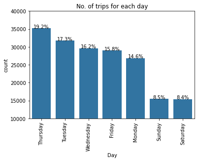

```python
base_color = sb.color_palette()[0]
sb.countplot(data=df_to_plot, x='day', color=base_color, order= most_trips_day.index);
n_trips = df_to_plot['day'].value_counts().sum()

locs, labels = plt.xticks(rotation=90);
for loc, label in zip(locs, labels):

    count = most_trips_day[label.get_text()]
    pct_string = '{:0.1f}%'.format(100*count/n_trips)

    plt.text(loc, count+2, pct_string, ha = 'center', color = 'black')
plt.xlabel('Day');
plt.ylim((10000,40000));

plt.title('No. of trips for each day');

from matplotlib import rcParams
rcParams['figure.figsize'] = 12,8
```

### Findining 2: The use of bikes occurs most in the hours to go to work (7.00, 8.00, 9.00) and the hours to leave work (16.00, 17.00, 18.00), the time to go at 8 am and leave at 5.00 pm is the peak time for bike use .

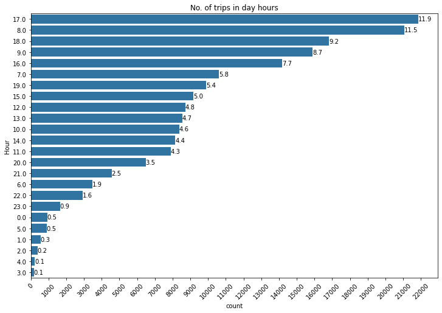

```python
base_color = sb.color_palette()[0]
hr_order = most_trips_hr.index
n_trips = df_to_plot['hour'].value_counts().sum()
max_hr = most_trips_hr.iloc[0]
max_prop = max_hr / n_trips
tick_props = np.arange(0, max_prop, 0.02)
tick_names = ['{:0.2f}'.format(v) for v in tick_props]
sb.countplot(data=df_to_plot, y='hour', color=base_color, order=hr_order);
for i in range (most_trips_hr.shape[0]):
    count = most_trips_hr.iloc[i]
    pct_string = '{:0.1f}'.format(100*count/n_trips)
    plt.text(count+1, i, pct_string, va='center')

ticks = np.arange(0,23000,1000)
labels = ['{}'.format(v) for v in ticks]
plt.xticks(ticks, labels,rotation=45);
plt.ylabel('Hour');
plt.title('No. of trips in day hours');

from matplotlib import rcParams
rcParams['figure.figsize'] = 12,7
```

### Findining 3: Unlike the weekdays , in holdays (weekends) The use of bikes occurs most in the hours of the mid-day from 11.00 A.m to 4.00 P.M .

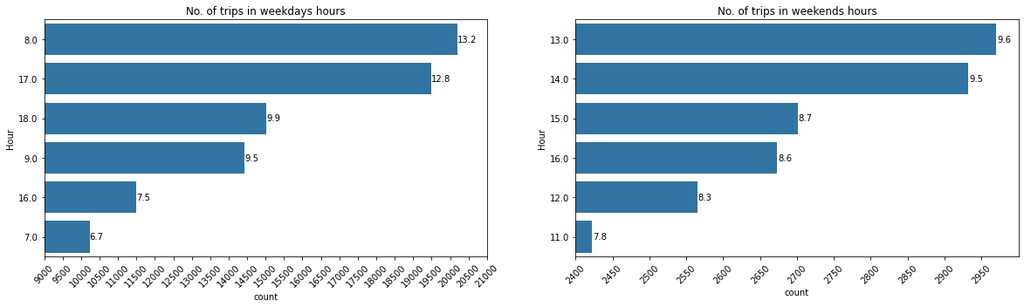

```python
plt.figure(figsize = [20, 5])

plt.subplot(1, 2, 1)
base_color = sb.color_palette()[0]
hr_order1 = most_trips_hr1.index
n_trips1 = df_to_plot_weekdays['hour'].value_counts().sum()
max_hr1 = most_trips_hr1.iloc[0]
max_prop = max_hr1 / n_trips1
tick_props = np.arange(0, max_prop, 0.02)
tick_names = ['{:0.2f}'.format(v) for v in tick_props]
sb.countplot(data=df_to_plot_weekdays, y='hour', color=base_color, order=hr_order1);
for i in range (most_trips_hr1.shape[0]):
    count = most_trips_hr1.iloc[i]
    pct_string = '{:0.1f}'.format(100*count/n_trips1)
    plt.text(count+1, i, pct_string, va='center')

ticks = np.arange(0,23000,500)
labels = ['{}'.format(v) for v in ticks]
plt.xticks(ticks, labels,rotation=45);
plt.ylabel('Hour');
plt.xlim((9000,21000));
plt.title('No. of trips in weekdays hours');

from matplotlib import rcParams
rcParams['figure.figsize'] = 12,7


plt.subplot(1, 2, 2)
base_color = sb.color_palette()[0]
hr_order2 = most_trips_hr2.index
n_trips2 = df_to_plot_weekends['hour'].value_counts().sum()
max_hr2 = most_trips_hr2.iloc[0]
max_prop = max_hr2 / n_trips2
tick_props = np.arange(0, max_prop, 0.02)
tick_names = ['{:0.2f}'.format(v) for v in tick_props]
sb.countplot(data=df_to_plot_weekends, y='hour', color=base_color, order=hr_order2);
for i in range (most_trips_hr2.shape[0]):
    count = most_trips_hr2.iloc[i]
    pct_string = '{:0.1f}'.format(100*count/n_trips2)
    plt.text(count+1, i, pct_string, va='center')

ticks = np.arange(0,3000,50)
labels = ['{}'.format(v) for v in ticks]
plt.xticks(ticks, labels,rotation=45);
plt.ylabel('Hour');
plt.xlim((2400,3000));
plt.title('No. of trips in weekends hours');

from matplotlib import rcParams
rcParams['figure.figsize'] = 12,7
```

### Findining 4: Subscribers are the largest proportion of bikes users with percentage of 89.2% of users.

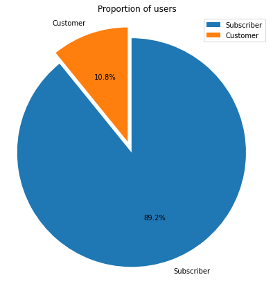

```python
sorted_counts = df_to_plot['user_type'].value_counts()
explode = (0, 0.1)

plt.pie(sorted_counts, labels = sorted_counts.index, explode=explode, autopct='%1.1f%%', startangle = 90, counterclock = False);

plt.axis('square');
plt.legend();
plt.title('Proportion of users');
```

### Findining 5: In weekends the percentage of customer users almost doubled to be 18.2% instead of 9.3% in weekdays .

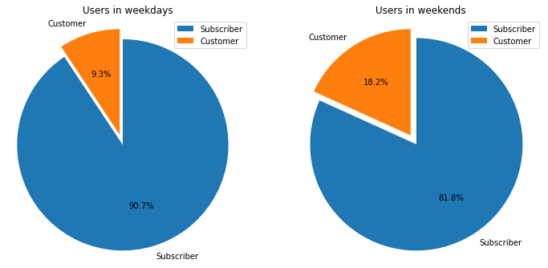

```python
plt.subplot(1, 2, 1)
sorted_counts1 = df_to_plot_weekdays['user_type'].value_counts()
explode = (0, 0.1)

plt.pie(sorted_counts1, labels = sorted_counts1.index, explode=explode, autopct='%1.1f%%', startangle = 90, counterclock = False);

plt.axis('square');
plt.legend();
plt.title('Users in weekdays');

plt.subplot(1, 2, 2)
sorted_counts2 = df_to_plot_weekends['user_type'].value_counts()
explode = (0, 0.1)

plt.pie(sorted_counts2, labels = sorted_counts2.index, explode=explode, autopct='%1.1f%%', startangle = 90, counterclock = False);
plt.legend();
plt.title('Users in weekends');

plt.axis('square');
```

### Findining 6: Most of bike-share users are in the age from 24 to 34 .

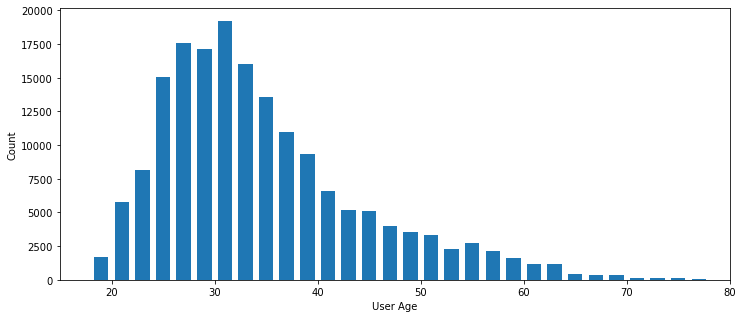

```python
plt.figure(figsize = [12, 5])

bins = np.arange(0, df_to_plot['user_age'].max()+2, 2)
plt.hist(data = df_to_plot, x = 'user_age', bins = bins , rwidth = 0.7);
plt.xlabel('User Age');
plt.ylabel('Count');
plt.xlim((15,80));
```

### Findining 7: Unlike males and females, The count of trips for gender of (other) has different distribution according to age .

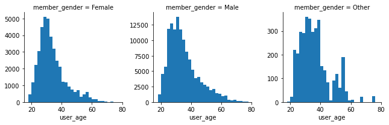

```python
plt.figure(figsize = [12, 5])

bins = np.arange(0, df_to_plot['user_age'].max()+2, 2)

g = sb.FacetGrid(data = df_to_plot, col = 'member_gender',sharey=False);
g.map(plt.hist, "user_age", bins = bins );

plt.xlim((15,80));
```

### Findining 8: The most number of trips for subscribers and customers almost happened in the same age period.

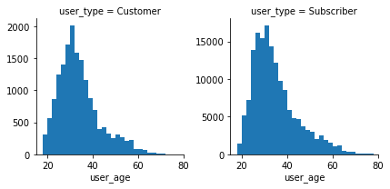

```python
plt.figure(figsize = [12, 5]);
bins = np.arange(0, df_to_plot['user_age'].max()+2, 2);

g = sb.FacetGrid(data = df_to_plot, col = 'user_type',sharey=False);
g.map(plt.hist, "user_age", bins = bins );
plt.xlim((15,80));
```

### Findining 9: The relation between age and trip count if bike share all trip or not .

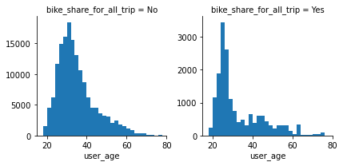

```python
plt.figure(figsize = [12, 5]) ;

bins = np.arange(0, df_to_plot['user_age'].max()+2, 2)

g = sb.FacetGrid(data = df_to_plot, col = 'bike_share_for_all_trip',sharey=False);
g.map(plt.hist, "user_age", bins = bins );

plt.xlim((15,80));
```

### Findining 10 : The largest start station in trips count is Market St at 10th St with 3904 trips .

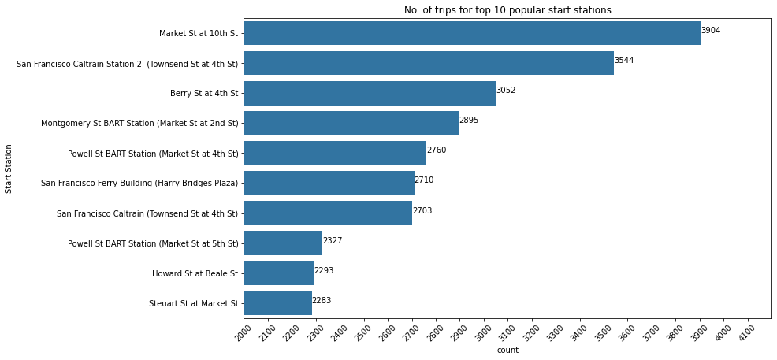

```python
base_color = sb.color_palette()[0]

m_order = most_start_station.index
ax = sb.countplot(data=df_to_plot, y='start_station_name', color=base_color, order=m_order);

for index, value in enumerate(most_start_station):
    plt.text(value, index,
             str(value))

ticks = np.arange(2000,4200,100)
labels = ['{}'.format(v) for v in ticks]
plt.xticks(ticks, labels,rotation=45);
plt.ylabel('Start Station');
plt.xlim((2000,4200));
plt.title('No. of trips for top 10 popular start stations');

from matplotlib import rcParams
rcParams['figure.figsize'] = 15,8
```

### Findining 11 : The less used start station is 16th St Depot with only 2 trips .

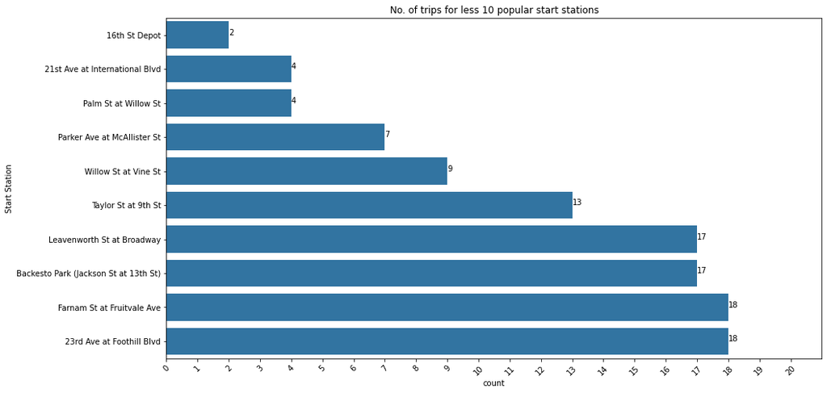

```python
base_color = sb.color_palette()[0]

l_order = less_start_station.index
ax = sb.countplot(data=df_to_plot, y='start_station_name', color=base_color, order=l_order);

for index, value in enumerate(less_start_station):
    plt.text(value, index,
             str(value))

ticks = np.arange(0,21,1)
labels = ['{}'.format(v) for v in ticks]
plt.xticks(ticks, labels,rotation=45);
plt.ylabel('Start Station');
plt.xlim((0,21));
plt.title('No. of trips for less 10 popular start stations');

from matplotlib import rcParams
rcParams['figure.figsize'] = 15,8
```

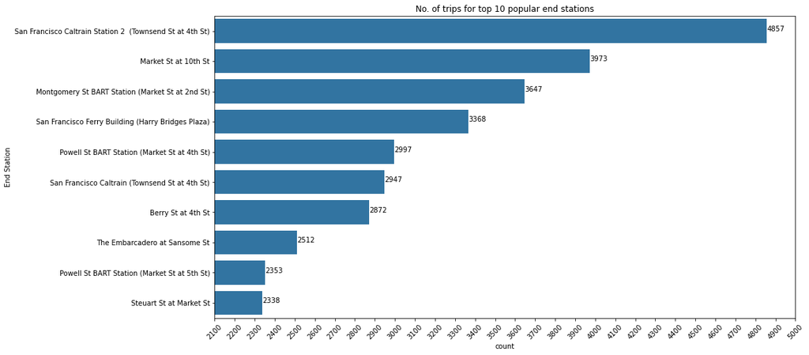

```python
base_color = sb.color_palette()[0]

m_end_order = most_end_station.index
ax = sb.countplot(data=df_to_plot, y='end_station_name', color=base_color, order=m_end_order);

for index, value in enumerate(most_end_station):
    plt.text(value, index,
             str(value))

ticks = np.arange(2000,5100,100)
labels = ['{}'.format(v) for v in ticks]
plt.xticks(ticks, labels,rotation=45);
plt.ylabel('End Station');
plt.xlim((2100,5000));
plt.title('No. of trips for top 10 popular end stations');

from matplotlib import rcParams
rcParams['figure.figsize'] = 15,8
```

### Findining 13 : The less used end station is Willow St at Vine Stt with only 5 trips .

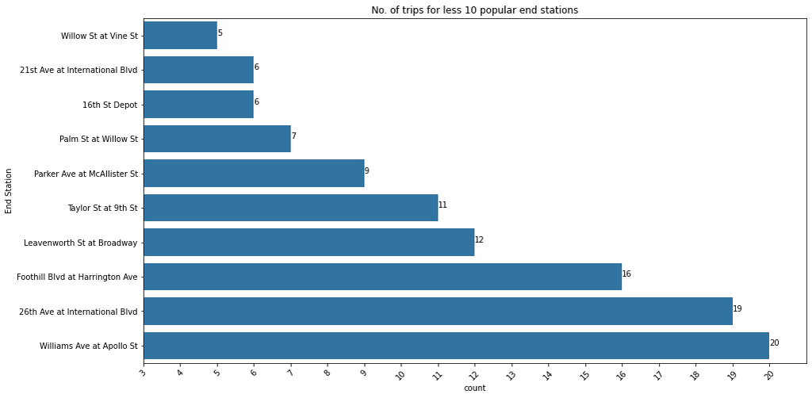

```python
base_color = sb.color_palette()[0]

l_s_order = less_end_station.index
ax = sb.countplot(data=df_to_plot, y='end_station_name', color=base_color, order=l_s_order);

for index, value in enumerate(less_end_station):
    plt.text(value, index,
             str(value))

ticks = np.arange(0,21,1)
labels = ['{}'.format(v) for v in ticks]
plt.xticks(ticks, labels,rotation=45);

plt.ylabel('End Station');
plt.xlim((3,21));
plt.title('No. of trips for less 10 popular end stations');

from matplotlib import rcParams
rcParams['figure.figsize'] = 15,8
```

### Findining 14 : The most relative start and end station happen when Berry St at 4th St is the start station and San Francisco Ferry Building (Harry Bridges Plaza) is the end station with total number of trips : 337 trips.

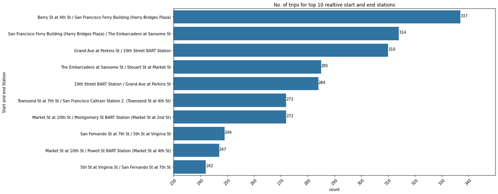

```python
base_color = sb.color_palette()[0]

m_r_order = most_relatives.index
ax = sb.countplot(data=df_to_plot, y='start_end_station', color=base_color, order=m_r_order);

for index, value in enumerate(most_relatives):
    plt.text(value, index,
             str(value))

ticks = np.arange(0,350,10)
labels = ['{}'.format(v) for v in ticks]
plt.xticks(ticks, labels,rotation=45);

plt.ylabel('Start and end Station');
plt.xlim((230,350));
plt.title('No. of trips for top 10 realtive start and end stations');

from matplotlib import rcParams
rcParams['figure.figsize'] = 15,8
```

### Findining 15 : The most bike used in ford go-bike system is bike with ID 4794 with total trips : 191 trips.

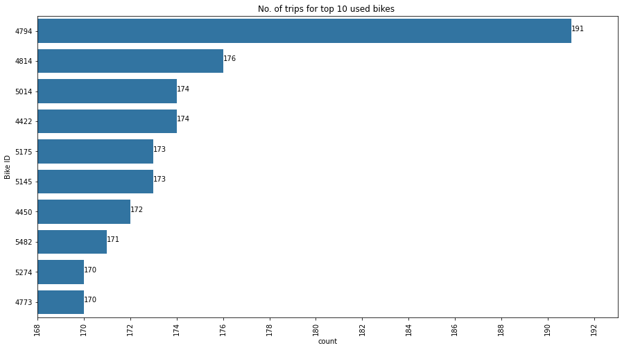

```python
base_color = sb.color_palette()[0]

bikes_order = most_bikes.index
ax = sb.countplot(data=df_to_plot, y='bike_id', color=base_color, order=bikes_order);

for index, value in enumerate(most_bikes):
    plt.text(value, index,
             str(value))

ticks = np.arange(0,210,2)
labels = ['{}'.format(v) for v in ticks]
plt.xticks(ticks, labels,rotation=90);
plt.ylabel('Bike ID');
plt.xlim((168,193));
plt.title('No. of trips for top 10 used bikes ');

from matplotlib import rcParams
rcParams['figure.figsize'] = 15,8
```

### Findining 16 : The most bikes used has centre duration time for trip around 10 minutes and trip duartion range from 5 to 15 minutes.

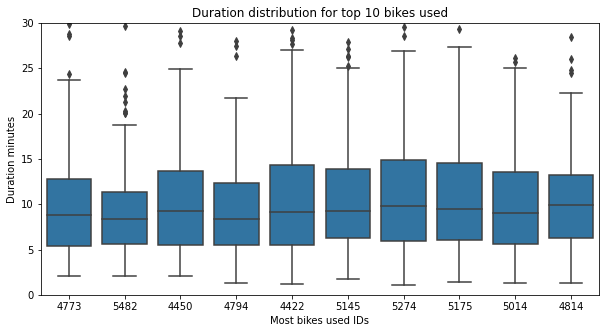

```python
plt.figure(figsize = [10, 5])
base_color = sb.color_palette()[0]
sb.boxplot(data=df_to_plot_most_used, x='bike_id', y='duration_minutes', color=base_color)
plt.ylim(0,30);
plt.ylabel('Duration minutes');
plt.xlabel('Most bikes used IDs');
plt.title('Duration distribution for top 10 bikes used');
```

### Findining 17 : The trips with duration range from 3 to 8 minutes have the largest count of trips in bike-share system.

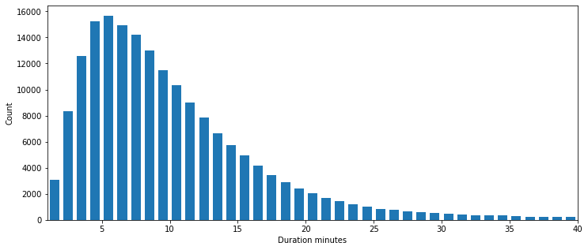

```python
plt.figure(figsize = [12, 5])

bins = np.arange(0, df_to_plot['duration_minutes'].max()+1, 1)
plt.hist(data = df_to_plot, x = 'duration_minutes', bins = bins , rwidth = 0.7);
plt.xlabel('Duration minutes');
plt.ylabel('Count');
plt.xlim((1,40));
```

### Findining 18: The count of trips for trip duaration according to user gender .

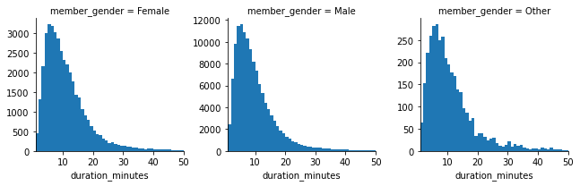

```python
plt.figure(figsize = [12, 5])

bins = np.arange(0, df_to_plot['duration_minutes'].max()+1, 1)

g = sb.FacetGrid(data = df_to_plot, col = 'member_gender',sharey=False);
g.map(plt.hist, "duration_minutes", bins = bins );

plt.xlim((1,50));
```

### Findining 19: The most number of trips for subscribers happen in less time duration than customers .

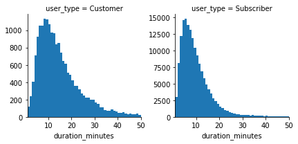

```python
plt.figure(figsize = [12, 5])

bins = np.arange(0, df_to_plot['duration_minutes'].max()+1, 1)

g = sb.FacetGrid(data = df_to_plot, col = 'user_type',sharey=False);
g.map(plt.hist, "duration_minutes", bins = bins );

plt.xlim((1,50));
```

### Findining 20 : The relation between time duration and trip count if bike share all trip or not .

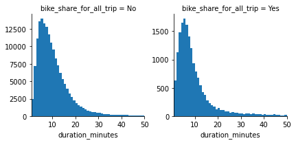

```python
plt.figure(figsize = [12, 5])

bins = np.arange(0, df_to_plot['duration_minutes'].max()+1, 1)

g = sb.FacetGrid(data = df_to_plot, col = 'bike_share_for_all_trip',sharey=False);
g.map(plt.hist, "duration_minutes", bins = bins );

plt.xlim((1,50));
```

### Findining 21 : the most bike used when bike shared all trip is bike with ID 3967 with total trips : 91 trips.

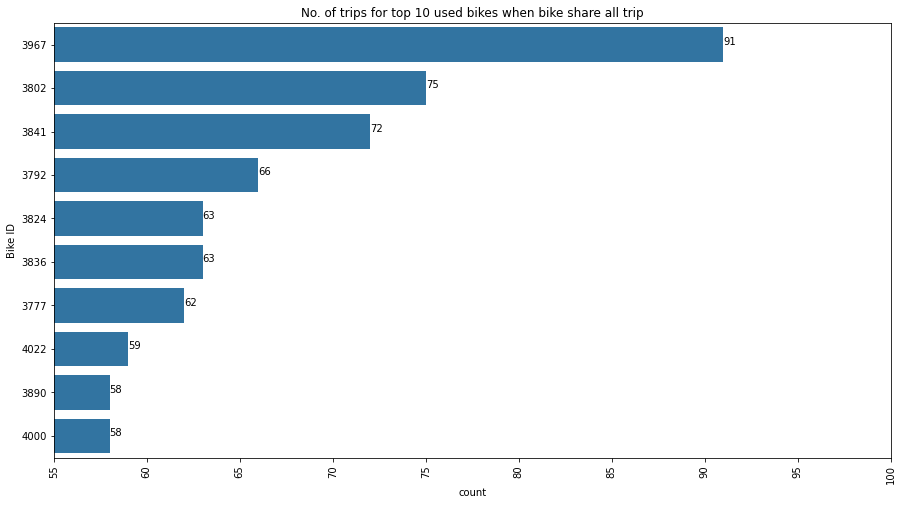

```python
base_color = sb.color_palette()[0]

bikes_order1 = bikes_all_trip.index
ax = sb.countplot(data=df_to_plot_all_trip, y='bike_id', color=base_color, order=bikes_order1);

for index, value in enumerate(bikes_all_trip):
    plt.text(value, index,
             str(value))

ticks = np.arange(0,105,5)
labels = ['{}'.format(v) for v in ticks]
plt.xticks(ticks, labels,rotation=90);
plt.ylabel('Bike ID');
plt.xlim((55,100));
plt.title('No. of trips for top 10 used bikes when bike share all trip');

from matplotlib import rcParams
rcParams['figure.figsize'] = 15,8
```

### Findining 22 : The trip duration for bikes that don't share all trip is larger than bikes that share all trip.

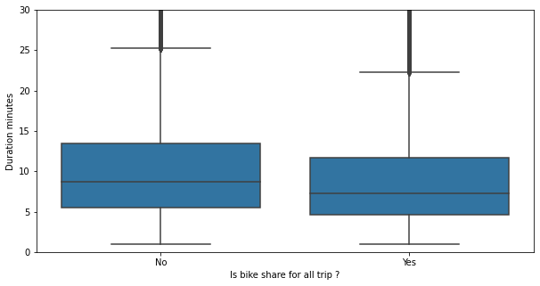

```python
plt.figure(figsize = [10, 5])
base_color = sb.color_palette()[0]
sb.boxplot(data=df_to_plot, x='bike_share_for_all_trip', y='duration_minutes', color=base_color)
plt.ylim(0,30);
plt.ylabel('Duration minutes');
plt.xlabel('Is bike share for all trip ?');
```

### Findining 23 : Bikes which don't share all trip has percentage 90.5% of total bikes used .

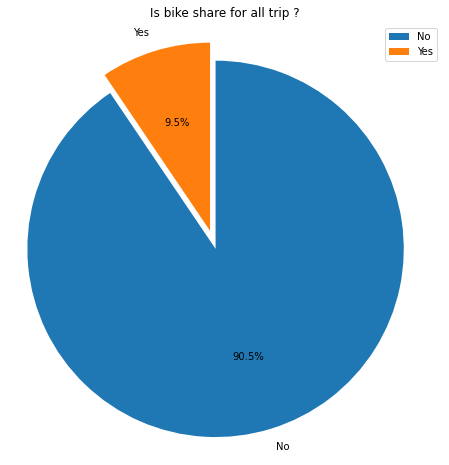

```python
sorted_counts = df_to_plot['bike_share_for_all_trip'].value_counts()
explode = (0, 0.1)

plt.pie(sorted_counts, labels = sorted_counts.index, explode=explode, autopct='%1.1f%%', startangle = 90, counterclock = False);

plt.axis('square');
plt.title('Is bike share for all trip ?');
plt.legend();
```

### Findining 24 : User age when using bike don't share all trip is larger thang user age using bike share all trip .

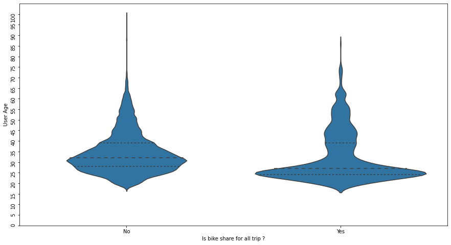

```python
base_color = sb.color_palette()[0]

sb.violinplot(data=df_to_plot, x='bike_share_for_all_trip', y='user_age', color=base_color, inner='quartile')

ticks = np.arange(0,105,5)
labels = ['{}'.format(v) for v in ticks]
plt.yticks(ticks, labels,rotation=90);
plt.ylabel('User Age');
plt.xlabel('Is bike share for all trip ?');
```

### Findining 25 : Age distribution for each gender .

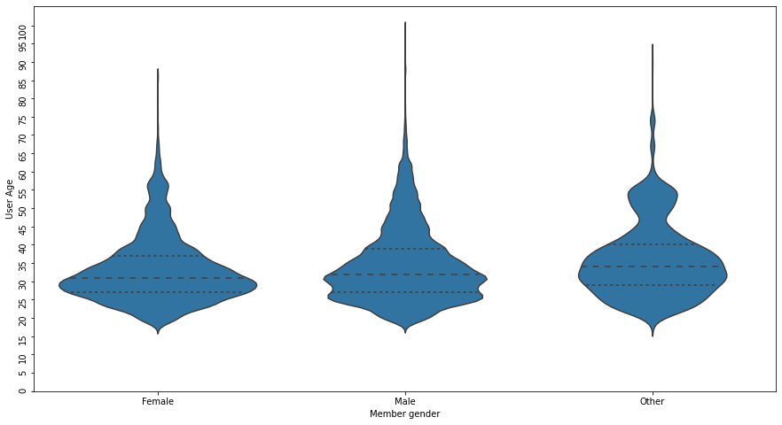

```python
base_color = sb.color_palette()[0]

sb.violinplot(data=df_to_plot, x='member_gender', y='user_age', color=base_color, inner='quartile')

ticks = np.arange(0,105,5)
labels = ['{}'.format(v) for v in ticks]
plt.yticks(ticks, labels,rotation=90);
plt.ylabel('User Age');
plt.xlabel('Member gender');
```

### Findining 26 : Trip duration time for customers is larger than subscribers .

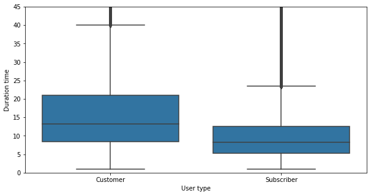

```python
plt.figure(figsize = [10, 5])
base_color = sb.color_palette()[0]
sb.boxplot(data=df_to_plot, x='user_type', y='duration_minutes', color=base_color)
plt.ylim(0,45);
plt.ylabel('Duration time');
plt.xlabel('User type');
```

### Findining 27 : Trip duration time for each gender .

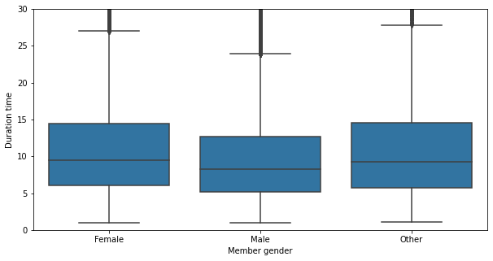

```python
plt.figure(figsize = [10, 5])
base_color = sb.color_palette()[0]
sb.boxplot(data=df_to_plot, x='member_gender', y='duration_minutes', color=base_color)
plt.ylim(0,30);
plt.ylabel('Duration time');
plt.xlabel('Member gender');
```

### Findining 28 : Males are more used for ford go-bike system.

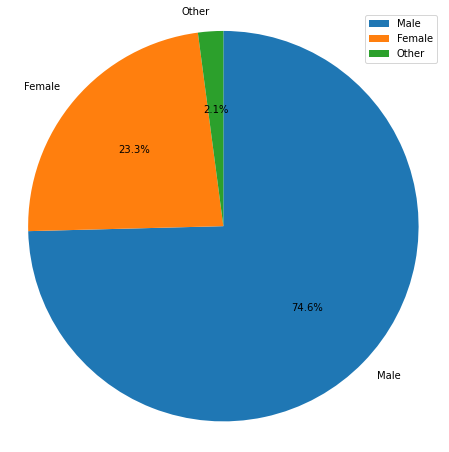

```python
plt.pie(most_gender_dur, labels = most_gender_dur.index, autopct='%1.1f%%', startangle = 90, counterclock = False);

plt.axis('square');
plt.legend();
```

### Findining 29 : Subscriber males are more used for ford go-bike system by 119069 trips.

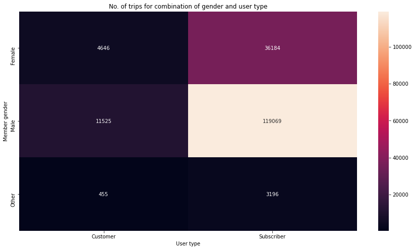

```python
ct_counts = df_to_plot.groupby(['member_gender', 'user_type']).size()
ct_counts = ct_counts.reset_index(name='count')
ct_counts = ct_counts.pivot(index = 'member_gender', columns = 'user_type', values = 'count')
sb.heatmap(ct_counts, annot = True, fmt = 'd');
plt.ylabel('Member gender');
plt.xlabel('User type');
plt.title('No. of trips for combination of gender and user type');
```

### Findining 30 :

### - there are no customers to use bikes for share all trip.

### - subscribers who use bikes don't share all trip are the most with 146185 trips.

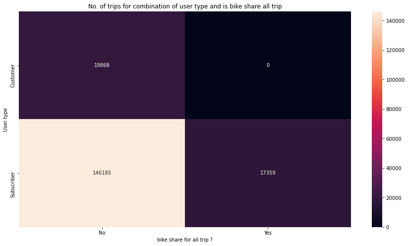

```python
ct_counts = df_to_plot.groupby(['user_type', 'bike_share_for_all_trip']).size()
ct_counts = ct_counts.reset_index(name='count')
ct_counts = ct_counts.pivot(index = 'user_type', columns = 'bike_share_for_all_trip', values = 'count')
sb.heatmap(ct_counts, annot = True, fmt = 'd');
plt.ylabel('User type');
plt.xlabel('bike share for all trip ?');
plt.title('No. of trips for combination of user type and is bike share all trip');
```

### Findining 31 : Males who use bikes don't share all trip are the most with 117510 trips.

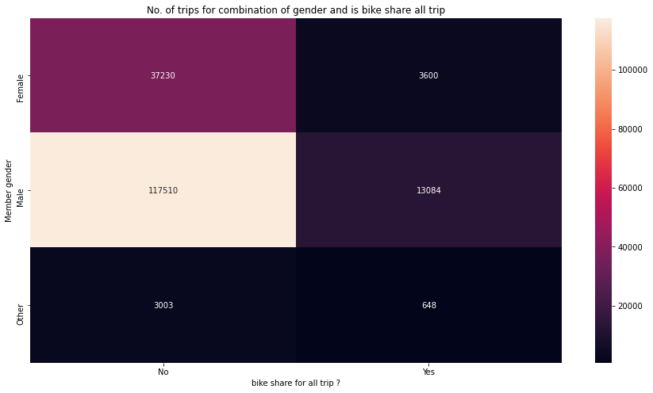

```python
ct_counts = df_to_plot.groupby(['member_gender', 'bike_share_for_all_trip']).size()
ct_counts = ct_counts.reset_index(name='count')
ct_counts = ct_counts.pivot(index = 'member_gender', columns = 'bike_share_for_all_trip', values = 'count')
sb.heatmap(ct_counts, annot = True, fmt = 'd');
plt.ylabel('Member gender');
plt.xlabel('bike share for all trip ?');
plt.title('No. of trips for combination of gender and is bike share all trip');
```

### Findining 32 : The relation between duration time for trips and user age.

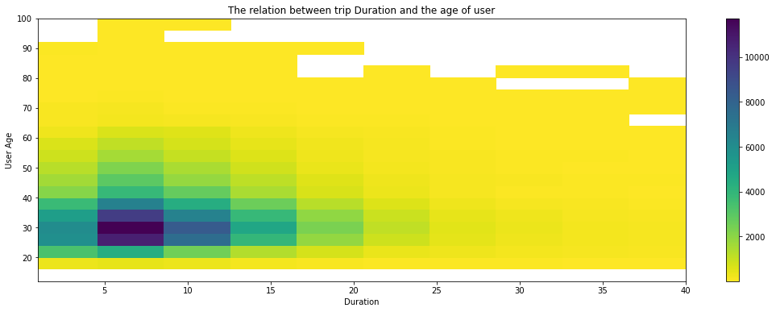

```python
plt.figure(figsize = [18, 6])
bins_x = np.arange(0.6, 100+4,4)
bins_y = np.arange(12, 100+4, 4)

plt.hist2d(data = df_to_plot, x = 'duration_minutes', y = 'user_age',cmin=0.5, cmap='viridis_r',bins = [bins_x, bins_y])
plt.colorbar()
plt.xlabel('Duration')
plt.ylabel('User Age');
plt.xlim((1,40));
plt.title('The relation between trip Duration and the age of user');
```